# ggplot2 avancé - problèmes et solutions

Charles Martin

29 octobre 2020

Cette formation assume que vous êtes déjà familières avec les fonctions de base de ggplot2. Si ce n’est pas le cas, prenez le temps de parcourir la formation de base (https://rive-numeri-lab.github.io/workshops/RapidDataViz) avant de poursuivre.

L’atelier d’aujourd’hui est organisé comme un *Problèmes et solutions*. J’ai essayé de ramasser les problèmes rencontrés le plus souvent quand on confronte les connaissances de base de ggplot2 à la réalité des sciences de l’environnement.

J’ai essayé d’organiser le matériel par thème, mais ce n’est rien de miraculeux, mon atelier est quand même un gigantesque *melting pot*.

# Faire ressortir de l’information

## Annotations

Une chose qui peut nous arriver de temps à autres est de vouloir ajouter à un graphique un petit bout d’information ne provenant pas directement de notre tableau de données. On peut évidemment s’en sortir en trichant et en ajouter ces données d’une façon ou d’une autre à nos données, mais les versions récentes de ggplot2 incluent une fonction `annotate`, qui nous permet de faire cela beaucoup plus proprement.

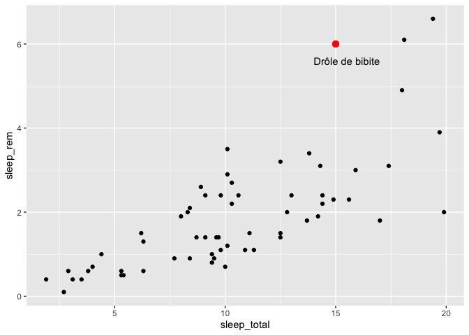

```r
library(ggplot2)

ggplot(msleep, aes(x = sleep_total, y = sleep_rem)) +
  geom_point() +
  annotate("point", x = 15, y = 6, color = "red", size = 3) +
  annotate("text", x = 15.5, y = 5.6, label = "Drôle de bibite")
```

Vous avez ainsi accès à toute la palette de geoms.

## Combiner des données de plusieurs sources dans un même graphique

Avant de vous lancer dans du copier-coller pour ajouter une série d’annotations, une chose intéressante à savoir est que l’on peut spéficier que certaines couches de points proviennent d’un tableau de données différent de celui passé à la fonction ggplot.

On pourrait par exemple se préparer un tableau avec les moyennes par type d’alimentation :

```r
library(dplyr)
moyennes <- msleep %>%
  group_by(vore) %>%
  summarize(
    sleep_total = mean(sleep_total, na.rm = TRUE),
    sleep_rem = mean(sleep_rem, na.rm = TRUE)
  )
moyennes
```

```
# A tibble: 5 x 3
  vore    sleep_total sleep_rem
  <chr>         <dbl>     <dbl>
1 carni         10.4       2.29
2 herbi          9.51      1.37
3 insecti       14.9       3.52
4 omni          10.9       1.96
5 <NA>          10.2       1.88
```

(remarquez que j’utilise na.rm pour permettre le calcul rapidement malgré les NA. Dans la vraie vie, il aurait fallu nettoyer correctement le tableau de données avant d’arriver ici…)

Pour se faciliter la vie, c’est une bonne idée de garder le même nom de variables comme j’ai fait ci-haut. Mais sinon, on pourrait simplement associer nos nouveaux noms avec un aes() dans ce geom…

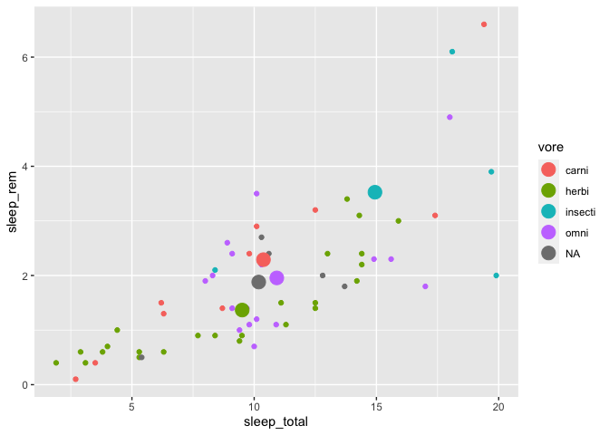

```r
ggplot(msleep, aes(x = sleep_total, y = sleep_rem, color = vore)) +
  geom_point() +
  geom_point(data = moyennes, size = 5)
```

Et un petit truc pour attirer l’attention sur certains points, une des choses que j’aime bien faire est d’ajouter un cercle vide un peu plus grand autour de chaque point.

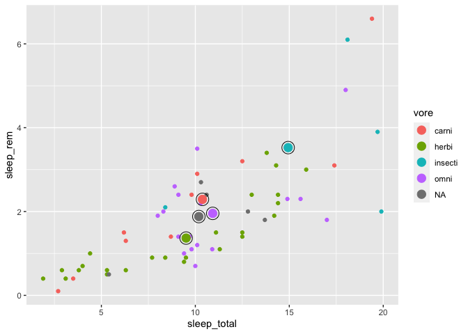

```r
ggplot(msleep, aes(x = sleep_total, y = sleep_rem, color = vore)) +
  geom_point() +
  geom_point(data = moyennes, size = 4) +
  geom_point(data = moyennes, size = 6, shape = 1, color = "black")
```

# Problèmes classiques en limnologie

## Jouer avec les axes

Le premier problème concret que nous verrons est : comment intégrer un second axes des Y à droite dans un graphique de ggplot2. Il s’agit en principe de quelque chose de simple, que l’on voit souvent en limnologie où l’on met par exemple sur un même graphique le pH et la température de l’eau.

Ce genre de choses n’est pas simple dans ggplot2, parce que l’auteur du package (Hadley Wickham) déteste cette façon de faire, entre autres parce qu’elle peut être facilement manipulée pour tromper le lecteur (https://stackoverflow.com/questions/3099219/ggplot-with-2-y-axes-on-each-side-and-different-scales/3101876#3101876).

Il a donc (malheureusement?) fait exprès que ce soit complexe d’ajouter un deuxième axes des Y, pour éviter que les gens s’en servent à la légère.

Quoiqu’il en soit, voici un petit jeu de données limnologie-style pour explorer comment nous pouvons faire pour mettre un deuxième axes des Y.

```r
limno <- data.frame(
  Profondeur = c(1,2,3,4),
  O2 = c(90, 75, 70,68),
  Temperature = c(12.1,10.8,10.4,8.5)
)
```

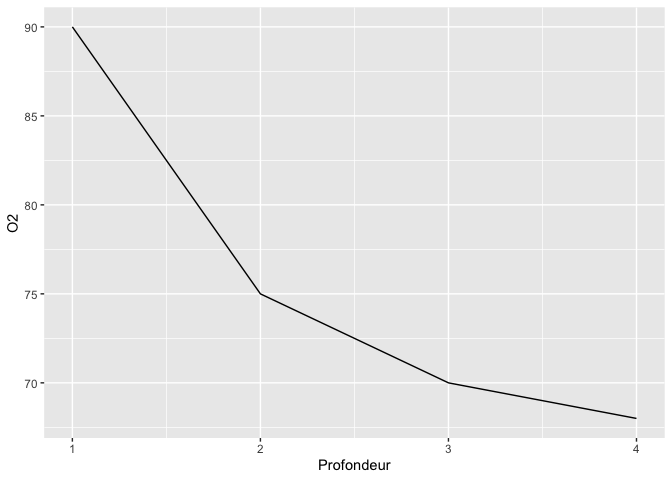

```r
ggplot(limno, aes(x = Profondeur)) +
  geom_line(aes(y = O2))
```

Alors, la première étape est d’ajouter notre deuxième série de données, ici la température :

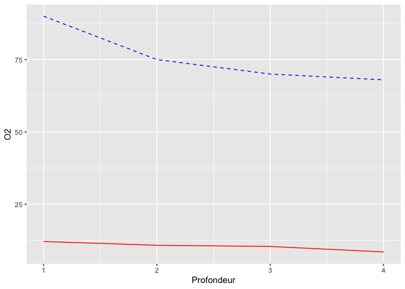

```r
ggplot(limno, aes(x = Profondeur)) +
  geom_line(aes(y = O2), color = "blue", linetype = "dashed") +
  geom_line(aes(y = Temperature), color = "red")
```

Remarquez que je modifie les propriétés des lignes à l’extérieur du “aes”, puisque cette information est identique pour chaque ligne du tableau.

Donc on a maintenant nos deux séries de chiffres, mais notre graphique ne sait pas qu’il faut mettre une autre échelle pour la température.

L’étape suivante est de se demander quelle transformation il faudrait appliquer pour ramener le maximum de température à la même hauteur que celui d’oxygène. Une façon rapide est de calculer le rapport du maximum entre nos deux variables : 90/12 = 7.5. La température doit donc être multiplié par 7.5

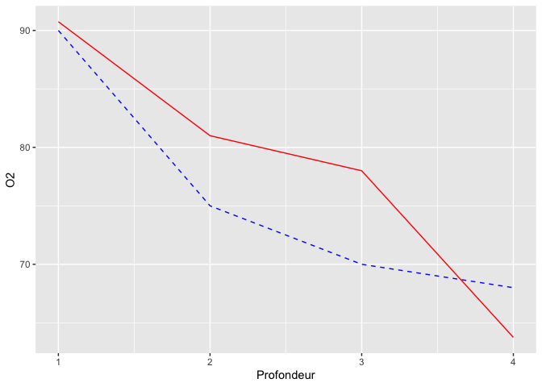

```r
ggplot(limno, aes(x = Profondeur)) +
  geom_line(aes(y = O2), color = "blue", linetype = "dashed") +
  geom_line(aes(y = Temperature*7.5), color = "red")
```

Maintenant que les données sont ajustées, il faut appliquer cette transformation à l’inverse à l’axe pour terminer l’ajustement :

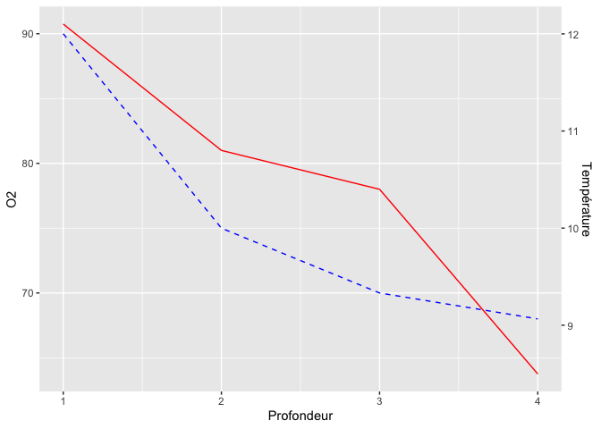

```r
ggplot(limno, aes(x = Profondeur)) +
  geom_line(aes(y = O2), color = "blue", linetype = "dashed") +
  geom_line(aes(y = Temperature*7.5), color = "red") +
  scale_y_continuous(sec.axis = sec_axis(~./7.5,name = "Température"))
```

Dans ce genre de graphique, il arrive aussi fréquemment que l’on veuille “flipper” les axes, pour mettre la profondeur en Y et nos deux autres mesures en X, pour imiter l’organisation spatiale dans un lac. Il existe pour cela la fonction coord_flip :

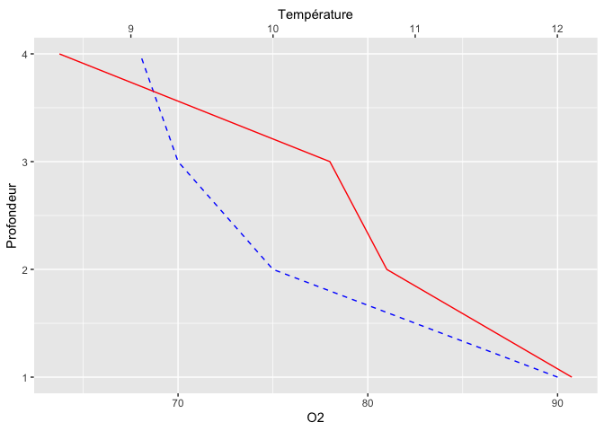

```r
ggplot(limno, aes(x = Profondeur)) +
  geom_line(aes(y = O2), color = "blue", linetype = "dashed") +
  geom_line(aes(y = Temperature*7.5), color = "red") +
  scale_y_continuous(sec.axis = sec_axis(~./7.5,name = "Température")) +
  coord_flip()
```

Remarquez que naturellement, si on veut vraiment imiter le lac, l’axe des X (présenté à la verticale) devrait aussi être inversé, avec la valeur de zéro en haut. On peut inverser un axe, comme ceci :

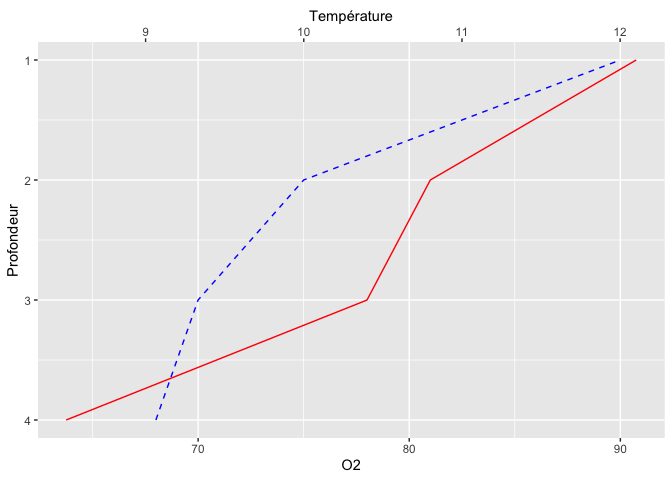

```r
ggplot(limno, aes(x = Profondeur)) +
  geom_line(aes(y = O2), color = "blue", linetype = "dashed") +
  geom_line(aes(y = Temperature*7.5), color = "red") +
  scale_y_continuous(sec.axis = sec_axis(~./7.5,name = "Température")) +
  coord_flip() +
  scale_x_reverse()
```

## Les expressions

Dernière chose tannante avec ce graphique, c’est que le symbole pour l’oxygène devrait avoir le *2* en indice, plus petit qu’un *2* ordinaire. On peut, pour se faire, utiliser la fonction `expression` qui nous permet d’écrire une formule mathématique, dans un langage ressemblant un peu au Latex.

On peut en profiter pour changer le thème en finalisant ce graphique.

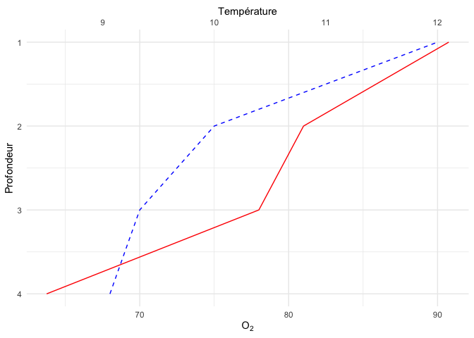

```r
ggplot(limno, aes(x = Profondeur)) +
  geom_line(aes(y = O2), color = "blue", linetype = "dashed") +
  geom_line(aes(y = Temperature*7.5), color = "red") +
  scale_y_continuous(sec.axis = sec_axis(~./7.5,name = "Température")) +
  coord_flip() +
  scale_x_reverse() +
  labs(y = expression(O[2])) +
  theme_minimal()
```

L’ensemble de la syntaxe pour écrire des expressions est définie dans cette page d’aide : https://stat.ethz.ch/R-manual/R-devel/library/grDevices/html/plotmath.html

Si on voulait par exemple écrire l’équation de la variance d’une population, le guide nous indique d’écrire ceci :

```r
msleep %>%
  ggplot() +
  annotate("text",x=1,y=1,size = 10,label=expression(
    sigma^2 = sum(
      over(
        (x[i]-bar(x))^2,
        n
      ),
      i==1,
      n)
  ))
```

```
Error: <text>:4:13: unexpected '='
3:   annotate("text",x=1,y=1,size = 10,label=expression(
4:     sigma^2 =
               ^
```

Et là, évidemment, ça ne fonctionne pas! Pourtant, on respecte tout ce qui écrit dans le guide Charles…

La nuance importante à comprendre est que le code utilisé pour écrire l’expression doit être du code qui respecte aussi la syntaxe de R. On aurait jamais eu le droit d’écrire `x^2=3` dans R.

La solution dans ce cas là est d’utiliser la fonction paste pour coller ensemble des morceaux qui sont valides individuellement, comme ceci :

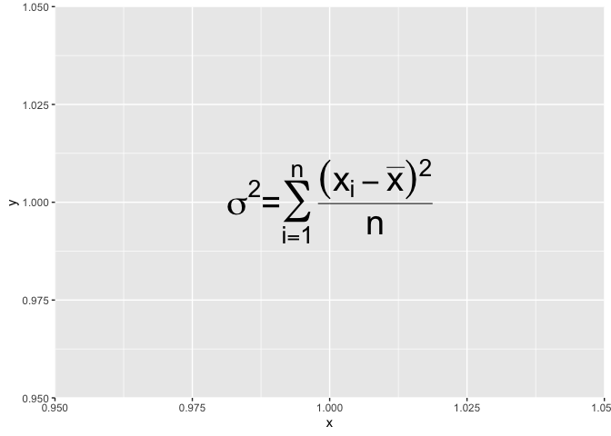

```r
msleep %>%
  ggplot() +
  annotate("text",x=1,y=1,size = 10,label=
             expression(paste(
                sigma^2,
                "=",
                sum(over((x[i]-bar(x))^2,n),i==1,n)
            ))
  )
```

Une fois l’idée du paste illustrée, remarquez que la vraie façon d’indiquer un “=” dans le guide est d’utiliser “==” ;-)

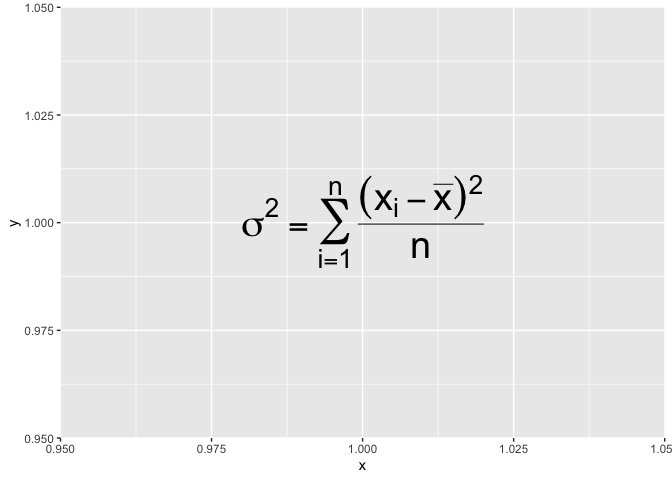

```r
msleep %>%
  ggplot() +
  annotate("text",x=1,y=1,size = 10,label=
             expression(paste(
                sigma^2 == sum(over((x[i]-bar(x))^2,n),i==1,n)
            ))
  )
```

# Problèmes classiques en écologie végétale

## Équation de régression

Un autre cas où nous avons souvent besoin d’ajouter des annotations à un graphique est lorsque nous traçons une régression.

La chose à savoir, c’est qu’il n’y a pas de façon simple d’ajouter l’équation en utilisant `geom_smooth(method = "lm")`. Cette méthode est faite pour explorer les données et non pas pour ajuster des modèles et en extraire les paramètres. La méthode que je vous montre ici vous sera utile dans beaucoup plus de situations qu’uniquement la régression linéaire.

Elle consiste à ajuster le modèle, pour ensuite ajouter les prédictions du modèle au tableau de données pour pouvoir tracer la droite.

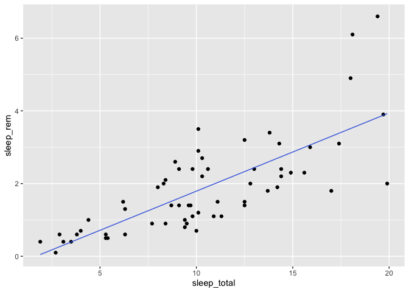

```r
library(tidyr)

bd <- msleep %>%
  select(sleep_total, sleep_rem) %>%
  drop_na

m <- lm(sleep_rem ~ sleep_total, data = bd)

bd <- bd %>%
  mutate(
    prediction = predict(m)
  )

bd %>%
  ggplot(aes(x = sleep_total, y = sleep_rem)) +
  geom_point() +
  geom_line(aes(y = prediction), color = "royalblue")
```

Pour ajouter l’équation, il faut d’abord trouver nos paramètres :

```r
summary(m)
```

```
Call:
lm(formula = sleep_rem ~ sleep_total, data = bd)

Residuals:
    Min      1Q  Median      3Q     Max
-1.9233 -0.5473 -0.1200  0.4791  2.7843

Coefficients:
            Estimate Std. Error t value Pr(>|t|)
(Intercept) -0.36132    0.27833  -1.298    0.199
sleep_total  0.21531    0.02459   8.756 2.92e-12 ***
---
Signif. codes:  0 '***' 0.001 '**' 0.01 '*' 0.05 '.' 0.1 ' ' 1

Residual standard error: 0.8634 on 59 degrees of freedom
Multiple R-squared:  0.5651,    Adjusted R-squared:  0.5578
F-statistic: 76.67 on 1 and 59 DF,  p-value: 2.916e-12
```

Puis on peut les ajouter avec une annotation de texte, que l’on peut combiner à la fonction `expression` si on veut être *fancy* :

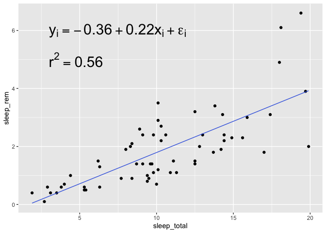

```r
bd %>%
  ggplot(aes(x = sleep_total, y = sleep_rem)) +
  geom_point() +
  geom_line(aes(y = prediction), color = "royalblue") +
  annotate("text",hjust = "left", x =3, y = 6, label = expression(
    y[i] == -0.36 + 0.22*x[i]+epsilon[i]
  ), size = 8) +
  annotate("text",hjust = "left",x =3, y = 5, label = expression(r^2 == 0.56), size = 8)
```

Remarquez que je modifie l’alignement horizontal du geom_text en utilisant “left” plutôt que “center” par défaut, ce qui permet d’aligner plus facilement nos deux annotations à gauche.

## Densités dans l’espace

Si jamais vous avez récolté les coordonnées d’une série d’individus et que vous vouliez tracer une carte des densités dans l’espace pour trouver des patrons, il existe une couche exprès pour cela dans ggplot2, qui se nomme geom_density_2d.

Pour illustrer la fonction, nous allons utiliser sleep_rem et sleep_total comme variables X et Y, mais le principe est exactement le même :

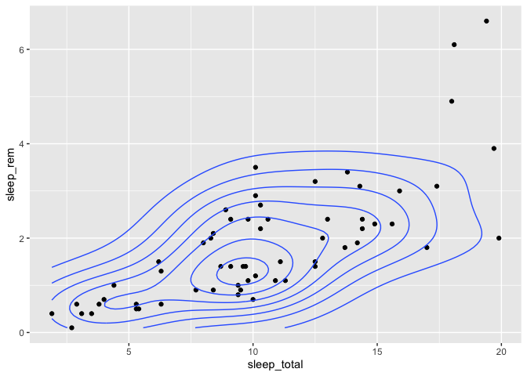

```r
msleep %>%
  ggplot(aes(x = sleep_total, y = sleep_rem)) +
  geom_point() +
  geom_density_2d()
```

Vous pouvez aussi choisir un remplissage plutôt que des lignes (ou une combinaison des deux avec les deux couches)

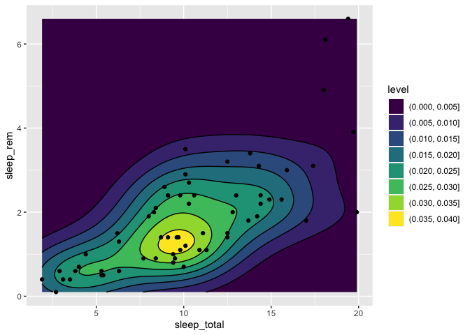

```r
msleep %>%
  ggplot(aes(x = sleep_total, y = sleep_rem)) +
  geom_density_2d_filled() +
  geom_density_2d(color = "black") +
  geom_point()
```

# Personnalisation

Maintenant, laissons un peu la limnologie et l’écologie végétale derrière-nous, et attaquons-nous à quelques trucs pour personnaliser nos graphiques.

## Choisir manuellement les couleurs d’une échelle discrète

Une des critique qui revient souvent à propos des ggplot2 est le choix des couleurs, qui ne sont pas très sérieuses aux yeux de certains.

Il existe deux façons de modifier une échelle de couleur. La première consiste à simplement choisir une nouvelle palette, à partir d’une liste pré-établie. Cette liste provient du package RColorBrewer et peut être consultée ici : https://www.r-graph-gallery.com/38-rcolorbrewers-palettes.html

Voyons comment on pourrait par exemple utiliser la palette Pastel1 dans un graphique :

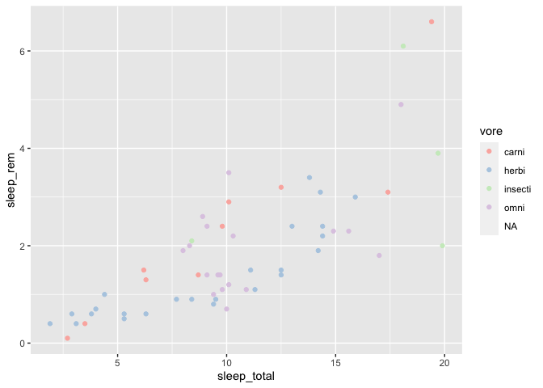

```r
ggplot(msleep, aes(x = sleep_total, y = sleep_rem)) +
  geom_point(aes(color = vore)) +
  scale_color_brewer(palette = "Pastel1")
```

On aurait pu aussi définir les couleurs de notre palette manuellement, une par une. Pour se faire, il existe deux façons de faire, soit avec le nom des couleurs :

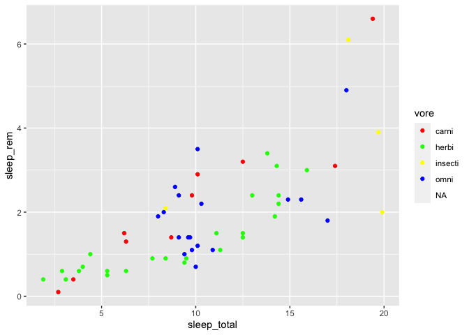

```r
ggplot(msleep, aes(x = sleep_total, y = sleep_rem)) +
  geom_point(aes(color = vore)) +
  scale_color_manual(values = c(
    "carni" = "red",
    "herbi" = "green",
    "insecti" = "yellow",
    "omni" = "blue"
  ))
```

Consultez ce pdf pour la liste de toutes les couleurs ayant un nom dans R : http://www.stat.columbia.edu/~tzheng/files/Rcolor.pdf

On aurait pu aussi construire manuellement nos couleurs à l’aide d’un code hexadécimal définissant la quantité de rouge, de bleu et de vert dans chaque couleur. Cela est très pratique pour copier par exemple une couleur précise retrouvée sur internet.

On aurait pu par exemple mettre notre graphique aux couleurs des Canadiens (https://teamcolorcodes.com/montreal-canadiens-color-codes/)

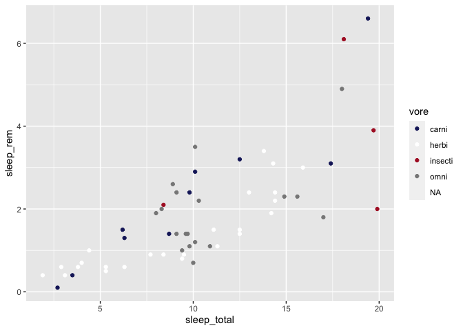

```r
ggplot(msleep, aes(x = sleep_total, y = sleep_rem)) +
  geom_point(aes(color = vore)) +
  scale_color_manual(values = c(
    "carni" = "#192168", # bleu
    "herbi" = "#ffffff", # blanc
    "insecti" = "#AF1E2D", # rouge
    "omni" = "#888888" # gris?
  ))
```

## Définir un gradient de couleur

Lorsque la couleur associée à nos points doit représenter un variable quantitative plutôt que qualitative, on peut définir manuellement le gradient de couleur qui sera utilisé par R.

Voyons d’abord un graphique avec le gradient de couleur par défaut de R :

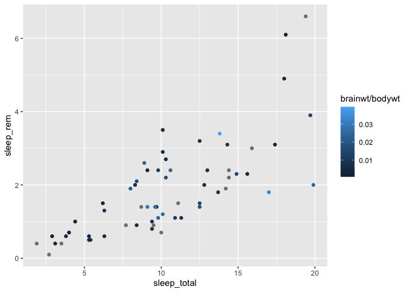

```r
ggplot(msleep, aes(x = sleep_total, y = sleep_rem)) +
  geom_point(aes(color = brainwt/bodywt))
```

On peut modifier l’échelle de couleur utilisée, avec la fonction scale_color_gradient :

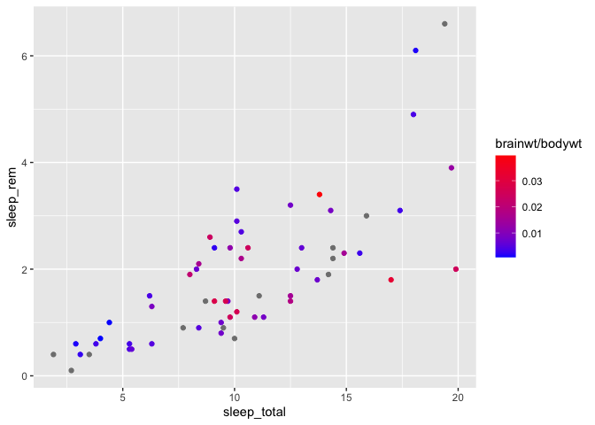

```r
ggplot(msleep, aes(x = sleep_total, y = sleep_rem)) +
  geom_point(aes(color = brainwt/bodywt)) +
  scale_color_gradient(low = "blue", high= "red")
```

Si on veut choisir quelle sera la couleur intermédiaire du gradient, on peut utiliser une seconde fonction, scale_color_gradient2 :

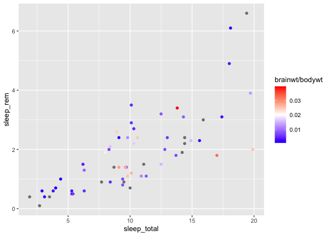

```r
ggplot(msleep, aes(x = sleep_total, y = sleep_rem)) +
  geom_point(aes(color = brainwt/bodywt)) +
  scale_color_gradient2(low = "blue", high= "red", mid = "white", midpoint = 0.02)
```

Si vous ne spécifiez pas de valeur pour le point milieu de votre gradient, ggplot assume que ce sera la valeur 0.

Enfin, vous pouvez utiliser un nombre arbitraire de couleurs dans votre palette avec scale_color_gradientn. Par exemple, pour refaire (approximativement) la palette de couleur du radar d’Environnement Canada :

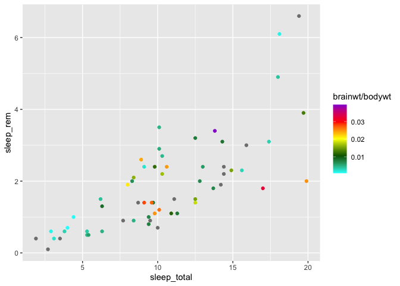

```r
ggplot(msleep, aes(x = sleep_total, y = sleep_rem)) +
  geom_point(aes(color = brainwt/bodywt)) +
  scale_color_gradientn(
    colors = c("cyan","darkgreen","yellow","red","darkviolet")
  )
```

Remarquez que toutes ces fonctions sont aussi disponibles pour les couleurs de remplissage. Remplacez simplement color pour fill, par exemple avec scale_fill_gradient2

Remarquez qu’ici aussi, on peut spécifier les couleurs avec un code hexadécimal. Par exemple, pour se faire un gradient tricolore :

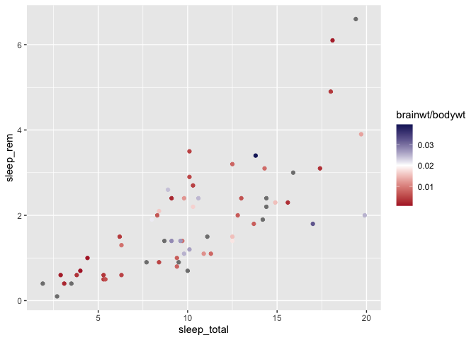

```r
ggplot(msleep, aes(x = sleep_total, y = sleep_rem)) +
  geom_point(aes(color = brainwt/bodywt)) +
  scale_color_gradient2(
    high = "#192168",
    mid = "#ffffff",
    low = "#af1e2d", # remarquez que l'on peut utiliser majuscules ou minuscules ici, sans problèmes
    midpoint = 0.02
  )
```

## Modifier TOUTES les étiquettes

Avec ggplot, toutes les étiquettes présentes dans un graphique peuvent être modifiées, mêmes certaines que vous ne savez peut-être pas quelles existent. La clé est de savoir leur nom :

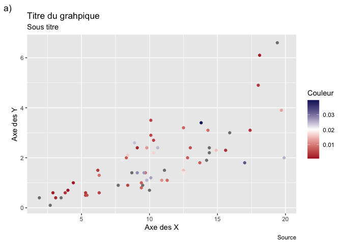

```r
ggplot(msleep, aes(x = sleep_total, y = sleep_rem)) +
  geom_point(aes(color = brainwt/bodywt)) +
  scale_color_gradient2(
    high = "#192168",
    mid = "#ffffff",
    low = "#af1e2d", # remarquez que l'on peut utiliser majuscules ou minuscules ici, sans problèmes
    midpoint = 0.02
  ) +labs(
    title = "Titre du grahpique",
    subtitle = "Sous titre",
    caption = "Source",
    tag = "a)",
    color = "Couleur",
    x = "Axe des X",
    y = "Axe des Y"
  )
```

Remarquez que l’on utilisera rarement title, subtitle et caption, puisqu’il est plus commun d’entrer ces éléments dans l’éditeur de texte. Remarquez aussi que vous avez accès à tous les autres éléments de la légende de la même façon (shape, fill, etc.)

## Les nuances de l’échelle log

Je vais maintenant discuter avec vous d’une opération somme toute banale, mais qui peut comporter plusieurs subtilités : mettre un axe en log.

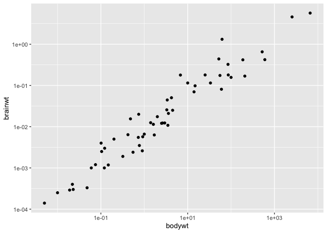

```r
ggplot(msleep, aes(x = bodywt, y = brainwt)) +
  geom_point() +
  scale_y_log10() +
  scale_x_log10()
```

Ces fonctions sont un raccourci, plutôt que de transformer manuellement vos données comme ceci :

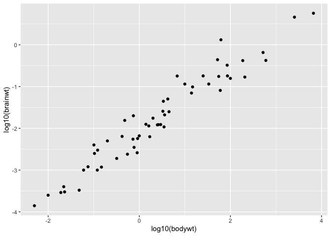

```r
ggplot(msleep, aes(x = log10(bodywt), y = log10(brainwt))) +
  geom_point()
```

Il pourrait cependant arriver que plutôt que transformer les valeurs, on ait besoin de seulement transformer l’axe, sans toucher aux valeurs comme tel. Il faut à ce moment utiliser coord_trans :

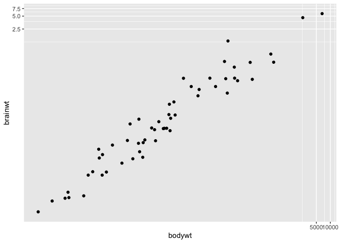

```r
ggplot(msleep, aes(x = bodywt, y = brainwt)) +
  geom_point() +
  coord_trans(x = "log10", y = "log10")
```

Vous pouvez entrer dans la transformation n’importe quelle fonction, par exemple la racine carrée :

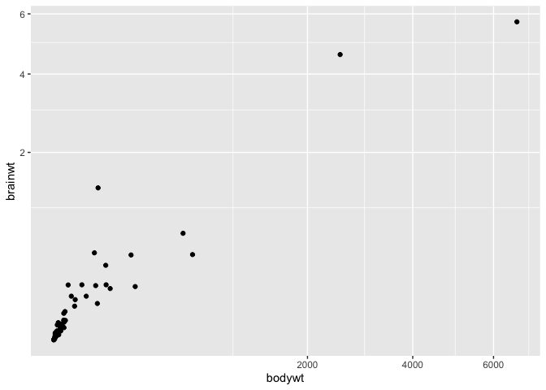

```r
ggplot(msleep, aes(x = bodywt, y = brainwt)) +
  geom_point() +
  coord_trans(x = "sqrt", y = "sqrt")
```

## Modifier les marques sur un axe

J’en profite ici pour vous montrer comment modifier manuellement les valeurs utilisées comme *tick marks* sur les axes.

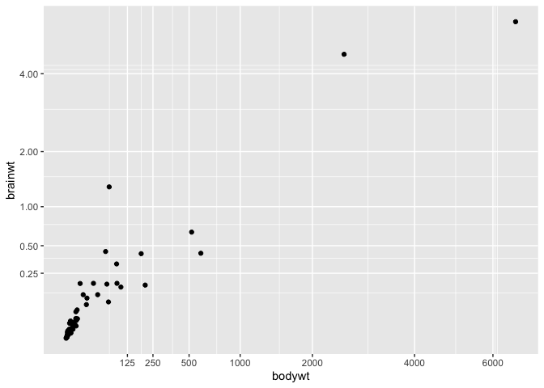

```r
ggplot(msleep, aes(x = bodywt, y = brainwt)) +
  geom_point() +
  coord_trans(x = "sqrt", y = "sqrt") +
  scale_x_continuous(breaks = c(125,250,500,1000,2000,4000,6000)) +
  scale_y_continuous(breaks = c(0.25,0.5,1,2,4,8))
```